# ME314 2018 Exam

Ionelia Buzatu

**INSTRUCTIONS:** Answer **four** of the **five** questions. If you answer five, we will base your grade on the best four of five. Each of your four best questions is weighted equally in the determination of your overall grade. (25 points each)

```r
library(tm)
library(quanteda)
library(quanteda.corpora)
library(readtext)
library(magrittr)
library(dplyr)
library(ggplot2)
library(boot)
library(glmnet)
library(readtext)
library(class)
library(heuristica)
library(e1071)
library(mlbench)
```

### Question 1

Using the `Boston` dataset (`MASS` package), predict the per capita crime rate using the other variables in this data set. In other words, per capita crime rate is the response, and the other variables are the predictors.

```r
data(Boston, package = "MASS")

# first attent to data analytics
head(Boston)
```

```
##      crim zn indus chas   nox    rm  age    dis rad tax ptratio  black
## 1 0.00632 18  2.31    0 0.538 6.575 65.2 4.0900   1 296    15.3 396.90
## 2 0.02731  0  7.07    0 0.469 6.421 78.9 4.9671   2 242    17.8 396.90
## 3 0.02729  0  7.07    0 0.469 7.185 61.1 4.9671   2 242    17.8 392.83
## 4 0.03237  0  2.18    0 0.458 6.998 45.8 6.0622   3 222    18.7 394.63
## 5 0.06905  0  2.18    0 0.458 7.147 54.2 6.0622   3 222    18.7 396.90
## 6 0.02985  0  2.18    0 0.458 6.430 58.7 6.0622   3 222    18.7 394.12
##   lstat medv
## 1  4.98 24.0
## 2  9.14 21.6
## 3  4.03 34.7
## 4  2.94 33.4
## 5  5.33 36.2
## 6  5.21 28.7
```

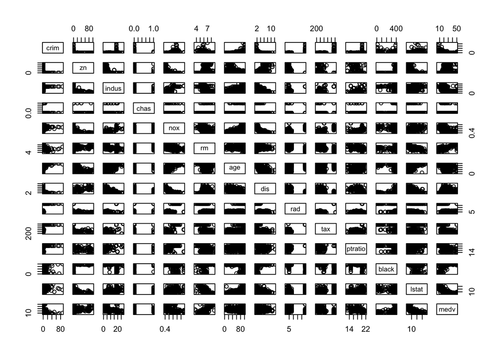

```r
pairs(Boston)
```

1. For each predictor, fit a simple (single-variable) linear regression model to predict the response. In which of the models is there a statistically significant association between the predictor and the response?

```r
## A for loop to get all single-variable linear regression models at once
for(i in colnames(Boston[,-1])) { #  response variable is not included here
  model = lm(crim~Boston[,i], data=Boston)
  names(model$coefficients)[2] = i # assign the variable name in the model summary
  summary = summary(model)
  print(summary)
  #single_coeff[[i]]= as.numeric(coef(model)[2])
  #print(single_coeff)
}
```

```
##
## Call:
## lm(formula = crim ~ Boston[, i], data = Boston)
##
## Residuals:
##    Min     1Q Median     3Q    Max
## -4.429 -4.222 -2.620  1.250 84.523
##
## Coefficients:
##             Estimate Std. Error t value Pr(>|t|)
## (Intercept)  4.45369    0.41722  10.675  < 2e-16 ***
## zn          -0.07393    0.01609  -4.594 5.51e-06 ***
## ---
## Signif. codes:  0 '***' 0.001 '**' 0.01 '*' 0.05 '.' 0.1 ' ' 1
##
## Residual standard error: 8.435 on 504 degrees of freedom
## Multiple R-squared:  0.04019,    Adjusted R-squared:  0.03828
## F-statistic:  21.1 on 1 and 504 DF,  p-value: 5.506e-06
##
##
## Call:
## lm(formula = crim ~ Boston[, i], data = Boston)
##
## Residuals:
##     Min      1Q  Median      3Q     Max
## -11.972  -2.698  -0.736   0.712  81.813
##
## Coefficients:
##             Estimate Std. Error t value Pr(>|t|)
## (Intercept) -2.06374    0.66723  -3.093  0.00209 **
## indus        0.50978    0.05102   9.991  < 2e-16 ***
## ---
## Signif. codes:  0 '***' 0.001 '**' 0.01 '*' 0.05 '.' 0.1 ' ' 1
##
## Residual standard error: 7.866 on 504 degrees of freedom
## Multiple R-squared:  0.1653, Adjusted R-squared:  0.1637
## F-statistic: 99.82 on 1 and 504 DF,  p-value: < 2.2e-16
##
##
## Call:
```

[output cut: 191 more lines]

```
##
## Residuals:
##    Min     1Q Median     3Q    Max
## -9.071 -4.022 -2.343  1.298 80.957
##
## Coefficients:
##             Estimate Std. Error t value Pr(>|t|)
## (Intercept) 11.79654    0.93419   12.63   <2e-16 ***
## medv        -0.36316    0.03839   -9.46   <2e-16 ***
## ---
## Signif. codes:  0 '***' 0.001 '**' 0.01 '*' 0.05 '.' 0.1 ' ' 1
##
## Residual standard error: 7.934 on 504 degrees of freedom
## Multiple R-squared:  0.1508, Adjusted R-squared:  0.1491
## F-statistic: 89.49 on 1 and 504 DF,  p-value: < 2.2e-16
```

```r
## coeff for each model. Did copied and paste, there was an error with single_coeff[[i]]
single_coef = c(-0.07393498,  0.50977633, -1.89277655, 31.24853120, -2.68405122,  0.10778623, -1.55090168, 0.61791093,  0.02974225,  1.15198279, -0.03627964,  0.54880478, -0.36315992)
```

**The F-statistic is far from 1 (with a small p-value), indicating evidence against the null hypothesis.** **Looking at the p-values associated with each predictor’s t-statistic, we see that there is a statistically significant association for each predictor and the response except for the chas.**

2. Fit a multiple regression model to predict the response using all of the predictors. Describe your results. For which predictors can we reject the null hypothesis $H_0 : \beta_j = 0$?

**We reject the null hypothesis for dis, rad, medv, zn and black, based on the p-values, F-statistic, and p-value of the F-statistic.**

```r
## multiple regression model
lm_model = lm(crim~., data = Boston)

## check for which predictors we can reject the null hypothesis $H_0 : \beta_j = 0$
summary(lm_model)
```

```
##
## Call:
## lm(formula = crim ~ ., data = Boston)
##
## Residuals:
##    Min     1Q Median     3Q    Max
## -9.924 -2.120 -0.353  1.019 75.051
##
## Coefficients:
##               Estimate Std. Error t value Pr(>|t|)
## (Intercept)  17.033228   7.234903   2.354 0.018949 *
## zn            0.044855   0.018734   2.394 0.017025 *
## indus        -0.063855   0.083407  -0.766 0.444294
## chas         -0.749134   1.180147  -0.635 0.525867
## nox         -10.313535   5.275536  -1.955 0.051152 .
## rm            0.430131   0.612830   0.702 0.483089
## age           0.001452   0.017925   0.081 0.935488
## dis          -0.987176   0.281817  -3.503 0.000502 ***
## rad           0.588209   0.088049   6.680 6.46e-11 ***
## tax          -0.003780   0.005156  -0.733 0.463793
## ptratio      -0.271081   0.186450  -1.454 0.146611
## black        -0.007538   0.003673  -2.052 0.040702 *
## lstat         0.126211   0.075725   1.667 0.096208 .
## medv         -0.198887   0.060516  -3.287 0.001087 **
## ---
## Signif. codes:  0 '***' 0.001 '**' 0.01 '*' 0.05 '.' 0.1 ' ' 1
##
## Residual standard error: 6.439 on 492 degrees of freedom
## Multiple R-squared:  0.454,  Adjusted R-squared:  0.4396
## F-statistic: 31.47 on 13 and 492 DF,  p-value: < 2.2e-16
```

```r
## excluding the Intercept coefficient
multiple_coeff = coef(lm_model)[-1]
```

3. How do your results from (a) compare to your results from (b)? Create a plot displaying the univariate regression coefficients from (a) on the $x$-axis, and the multiple regression coefficients from (b) on the $y$-axis. That is, each predictor is displayed as a single point in the plot. Its coefficient in a simple linear regression model is shown on the $x$-axis, and its coefficient estimate in the multiple linear regression model is shown on the $y$-axis. Hint: To get the coefficients from a fitted regression model, you can use `coef()`. Note that you are not interested in the intercept.

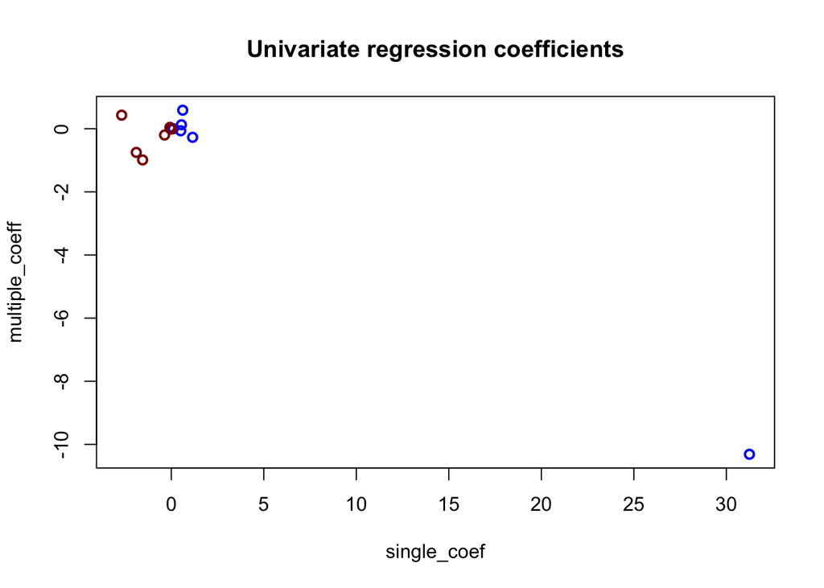

```r
## blue is y-axis and dark red is x-axis
## there is high similaity between the coefficents from the single-variable linear regression models and the multiple regression model except for the nox -10.313534912 (blue) which lies far from the others.
plot(x = single_coef, y = multiple_coeff, main= "Univariate regression coefficients", col = c("dark red", "blue"), lwd  =2)
```

### Question 2

Using the `Boston` data set, fit classification models in order to predict whether a given suburb has a crime rate above or below the median. Produce a confusion matrix for, and describe the findings from your model, for each of:

1. logistic regression

```r
# ## binary variable `crim01`, containg 1 if `crim` contains a value above its median, and a 0 if `crim` contains a value below its median
crim01  = rep(0, length(Boston$crim))
median = median(Boston$crim)
crim01[Boston$crim > median] <- 1

#merge them into a data frame object
Auto <- data.frame(crim01, Boston)
#
# #fisrt 20
# Auto$crim01[1:20]
#
# ## exploration
# cor(Auto[,-9])
# pairs(Auto)
#
# head(Auto)
# head(train)
# ## train and test sets
# train_1 <-  Auto[1:350,]
# test_1 <-   Auto[351:506,]
#
# crim01.test <-  test_1$crim01
#
# # LR model
# # glm.fit <-  glm(crim01 ~., data = train_!, family = binomial)
# # glm.probs <-  predict(glm.fit, test_!, type = "response")
# # glm.pred <-  rep(0, length(glm.probs))
# # glm.pred[glm.probs > 0.5] <- 1
#
# # estimate the test error
# test_error = mean(glm.pred  !=  crim01.test)
```

2. kNN

```r
#split data into train and test sets
train <-  Auto[1:350,]
test <-   Auto[351:506,]
crim01.test <-  test$crim01



dim(Auto)
```

```
## [1] 506  15
```

```r
str(train)
```

```
## 'data.frame':    350 obs. of  15 variables:
##  $ crim01 : num  0 0 0 0 0 0 0 0 0 0 ...
##  $ crim   : num  0.00632 0.02731 0.02729 0.03237 0.06905 ...
##  $ zn     : num  18 0 0 0 0 0 12.5 12.5 12.5 12.5 ...
##  $ indus  : num  2.31 7.07 7.07 2.18 2.18 2.18 7.87 7.87 7.87 7.87 ...
##  $ chas   : int  0 0 0 0 0 0 0 0 0 0 ...
##  $ nox    : num  0.538 0.469 0.469 0.458 0.458 0.458 0.524 0.524 0.524 0.524 ...
##  $ rm     : num  6.58 6.42 7.18 7 7.15 ...
##  $ age    : num  65.2 78.9 61.1 45.8 54.2 58.7 66.6 96.1 100 85.9 ...
##  $ dis    : num  4.09 4.97 4.97 6.06 6.06 ...
##  $ rad    : int  1 2 2 3 3 3 5 5 5 5 ...
##  $ tax    : num  296 242 242 222 222 222 311 311 311 311 ...
##  $ ptratio: num  15.3 17.8 17.8 18.7 18.7 18.7 15.2 15.2 15.2 15.2 ...
##  $ black  : num  397 397 393 395 397 ...
##  $ lstat  : num  4.98 9.14 4.03 2.94 5.33 ...
##  $ medv   : num  24 21.6 34.7 33.4 36.2 28.7 22.9 27.1 16.5 18.9 ...
```

```r
# bind the variables
train.X <-  cbind(train$zn, train$indus, train$chas, train$nox, train$rm, train$age, train$dis, train$rad, train$tax, train$ptratio, train$black, train$lstat, train$medv)
test.X <-  cbind(test$zn, test$indus, test$chas, test$nox, test$rm, test$age, test$dis, test$rad, test$tax, test$ptratio, test$black, test$lstat, test$medv)
train.crim01 <- train$crim01

# reproducible results
set.seed(1)

# KNN (k=1)
knn.pred <-  knn(train.X, test.X, train.crim01, k = 1)
mean(knn.pred != crim01.test) # test error 0.5961538
```

```
## [1] 0.5961538
```

```r
# KNN (k=10)
knn.pred <-  knn(train.X, test.X, train.crim01, k = 10)
mean(knn.pred != crim01.test) #test error  0.05769231
```

```
## [1] 0.05769231
```

```r
# KNN (k=100)
knn.pred <-  knn(train.X, test.X, train.crim01, k = 100)
mean(knn.pred !=  crim01.test) # test error 0.75
```

```
## [1] 0.75
```

```r
# KNN (k=300)
knn.pred <-  knn(train.X, test.X, train.crim01, k = 300)
mean(knn.pred !=  crim01.test) # test error 0.8653846
```

```
## [1] 0.8653846
```

3. (**bonus**) Naive Bayes predictors of your outcome. (Use the **e1071** package for this.)

```r
## NB

## fcatorise 'crim01'
naive_Auto = naiveBayes(as.factor(crim01)~., data = Auto)

## make prediction using the test set
pred = predict(naive_Auto, Auto, type = "class")

## check the model
table(pred, Auto$crim01, dnn=c("Prediction","Actual"))
```

```
##           Actual
## Prediction   0   1
##          0 243  19
##          1  10 234
```

**Note:** You do not have to split the data into test and training sets here. Just predict on the training sample, which consists of the entire dataset.

### Question 3

1. Give the standard error of the median for the `crim` variable from `data(Boston, package = "MASS")`.

```r
# This is a very high stand. error
sd(Boston$crim)/sqrt(length(Boston$crim)) * 1.253    # 0.4791288
```

```
## [1] 0.4791288
```

2. Estimate a bootstrapped standard error for the coefficient of `medv` in a logistic regression model of the above/below median of crime binary variable from question 2, with `medv`, `indus`, `age`, `black`, and `ptratio` as predictors. Compare this to the asymptotic standard error from the maximum likelihood estimation (reported by `summary.glm()`).

```r
# pairs(Auto)
# head(Boston)
# head(Auto)
get.coeffic = function(data, indices){
  data    = data[indices,]
  mylogit = glm(crim01~medv +indus +age +black +ptratio, data=data, family="binomial")
  summary(mylogit)
  return(coef(mylogit)) ## $coefficients
}

## maximum likelihood estimation of the standard error of the coefficient of `medv` is 0.019482
summary.glm(glm(crim01~medv +indus +age +black +ptratio, data=Auto, family="binomial"))
```

```
##
## Call:
## glm(formula = crim01 ~ medv + indus + age + black + ptratio,
##     family = "binomial", data = Auto)
##
## Deviance Residuals:
##     Min       1Q   Median       3Q      Max
## -3.2161  -0.5891  -0.0811   0.6108   2.2380
##
## Coefficients:
##              Estimate Std. Error z value Pr(>|z|)
## (Intercept) -2.383696   2.667672  -0.894  0.37156
## medv         0.061370   0.019482   3.150  0.00163 **
## indus        0.135512   0.026589   5.097 3.46e-07 ***
## age          0.043247   0.006185   6.992 2.71e-12 ***
## black       -0.015597   0.005442  -2.866  0.00416 **
## ptratio      0.127227   0.070994   1.792  0.07312 .
## ---
## Signif. codes:  0 '***' 0.001 '**' 0.01 '*' 0.05 '.' 0.1 ' ' 1
##
## (Dispersion parameter for binomial family taken to be 1)
##
##     Null deviance: 701.46  on 505  degrees of freedom
## Residual deviance: 401.09  on 500  degrees of freedom
## AIC: 413.09
##
## Number of Fisher Scoring iterations: 7
```

```r
## bootstrap estimators
boot(data = Auto, statistic = get.coeffic, R = 1000) # 4.723151983
```

```
##
## ORDINARY NONPARAMETRIC BOOTSTRAP
##
##
## Call:
## boot(data = Auto, statistic = get.coeffic, R = 1000)
##
##
## Bootstrap Statistics :
##        original       bias    std. error
## t1* -2.38369614  1.811901934 4.770393636
## t2*  0.06137039  0.001059282 0.017910114
## t3*  0.13551200  0.001277548 0.036081781
## t4*  0.04324691  0.001305325 0.006512087
## t5* -0.01559721 -0.005302878 0.012287676
## t6*  0.12722722  0.006134553 0.071769588
```

### Question 4

Using `quanteda`, construct an English language dictionary for “populism” for English, using the word patterns found in Appendix B of Rooduijn, Matthijs, and Teun Pauwels. 2011. “Measuring Populism: Comparing Two Methods of Content Analysis.” *West European Politics* 34(6): 1272–83.

Use this dictionary to measure the relative amount of populism, as a total of all words in, the `data_corpus_irishbudget2010` when these are grouped by political party. Hint: You will need to make two dfm objects, one for all words, and one for the dictionary, and get a proportion. Plot the proportions by party using a dotchart.

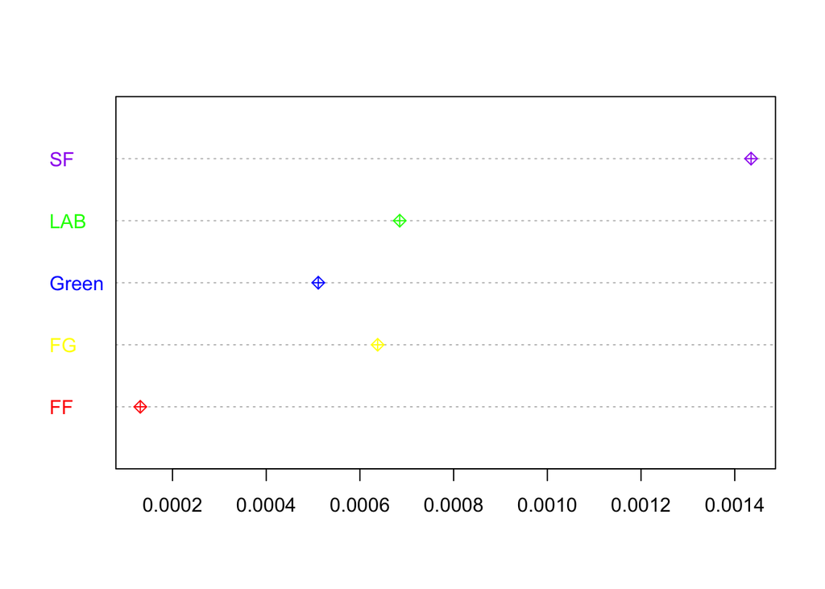

```r
data("data_corpus_irishbudget2010")

# dictionary from Table B
Dic = dictionary(list(populism = c("eliit*", "consensus*", "undemocratic*", "referend*", "corrupt*", "propagand*", "politici*", "*deceit*", "*deceiv*","*betray*", "shame*", "scandal*",
"truth*", "dishonest*", "establishm*", "ruling*")))

# first one
dfm_data_group = dfm(data_corpus_irishbudget2010, groups = "party")
# second one
dfm21 = dfm(dfm_data_group , dictionary = Dic)

proportion = ntoken(dfm21) / ntoken(dfm_data_group)
dotchart(proportion, pch = 9 , color = c("red", "yellow", "blue", "green", "purple"))
```

### Question 5

Here we will use k-means clustering to see if we can produce groupings by party of the 1984 US House of Representatives, based on their voting records from 16 votes. This data is the object `HouseVotes84` from the `mlbench` package. Since this is stored as a list of factors, use the following code to transform it into a method that will work with the `kmeans()` function.

```r
data(HouseVotes84, package = "mlbench")
head(HouseVotes84)
```

```
##        Class   V1 V2 V3   V4   V5 V6 V7 V8 V9 V10  V11  V12 V13 V14 V15
## 1 republican    n  y  n    y    y  y  n  n  n   y <NA>    y   y   y   n
## 2 republican    n  y  n    y    y  y  n  n  n   n    n    y   y   y   n
## 3   democrat <NA>  y  y <NA>    y  y  n  n  n   n    y    n   y   y   n
## 4   democrat    n  y  y    n <NA>  y  n  n  n   n    y    n   y   n   n
## 5   democrat    y  y  y    n    y  y  n  n  n   n    y <NA>   y   y   y
## 6   democrat    n  y  y    n    y  y  n  n  n   n    n    n   y   y   y
##    V16
## 1    y
## 2 <NA>
## 3    n
## 4    y
## 5    y
## 6    y
```

```r
#test = unclass(HouseVotes84[,2])
HouseVotes84num <- as.data.frame(lapply(HouseVotes84[, -1], unclass))
HouseVotes84num[is.na(HouseVotes84num)] <- 0
set.seed(2)  # make sure you do this before step b below
```

1. What does each line of that code snippet do, and why was this operation needed? What is the `-1` indexing for?

2. Perform a kmeans clustering on the votes only data, for 2 classes, after setting the seed to 2 as per above. Construct a table comparing the actual membership of the Congressperson’s party (you will find this as one of the variables in the `HouseVotes84` data) to the cluster assigned by the kmeans procedure. Report the
   1. accuracy
   2. precision
   3. recall = sensitivity

```r
# accuracy = (true positive + true negatve) / all (100 times this is the same as percentCorrect)
# sensitivity = true pasitive rate = true positive / all positive (sensitivity is also called recall)
# 2 repubblican
# 1 democratic

set.seed(2)

kmeans_model = kmeans(HouseVotes84num, 2)
kmeans_model$cluster[kmeans_model$cluster == 2]
```

```
##   [1] 2 2 2 2 2 2 2 2 2 2 2 2 2 2 2 2 2 2 2 2 2 2 2 2 2 2 2 2 2 2 2 2 2 2 2
##  [36] 2 2 2 2 2 2 2 2 2 2 2 2 2 2 2 2 2 2 2 2 2 2 2 2 2 2 2 2 2 2 2 2 2 2 2
##  [71] 2 2 2 2 2 2 2 2 2 2 2 2 2 2 2 2 2 2 2 2 2 2 2 2 2 2 2 2 2 2 2 2 2 2 2
## [106] 2 2 2 2 2 2 2 2 2 2 2 2 2 2 2 2 2 2 2 2 2 2 2 2 2 2 2 2 2 2 2 2 2 2 2
## [141] 2 2 2 2 2 2 2 2 2 2 2 2 2 2 2 2 2 2 2 2 2 2 2 2 2 2 2 2 2 2 2 2 2 2 2
## [176] 2 2 2 2 2 2 2 2 2 2 2 2 2 2 2 2 2 2 2 2 2 2 2 2 2 2 2 2 2 2
```

```r
kmeans_model$cluster[kmeans_model$cluster == 1]
```

```
##   [1] 1 1 1 1 1 1 1 1 1 1 1 1 1 1 1 1 1 1 1 1 1 1 1 1 1 1 1 1 1 1 1 1 1 1 1
##  [36] 1 1 1 1 1 1 1 1 1 1 1 1 1 1 1 1 1 1 1 1 1 1 1 1 1 1 1 1 1 1 1 1 1 1 1
##  [71] 1 1 1 1 1 1 1 1 1 1 1 1 1 1 1 1 1 1 1 1 1 1 1 1 1 1 1 1 1 1 1 1 1 1 1
## [106] 1 1 1 1 1 1 1 1 1 1 1 1 1 1 1 1 1 1 1 1 1 1 1 1 1 1 1 1 1 1 1 1 1 1 1
## [141] 1 1 1 1 1 1 1 1 1 1 1 1 1 1 1 1 1 1 1 1 1 1 1 1 1 1 1 1 1 1 1 1 1 1 1
## [176] 1 1 1 1 1 1 1 1 1 1 1 1 1 1 1 1 1 1 1 1 1 1 1 1 1 1 1 1 1 1 1 1 1 1 1
## [211] 1 1 1 1 1 1 1 1 1 1 1 1 1 1 1 1 1 1 1 1
```

```r
tab = table(kmeans_model$cluster, HouseVotes84$Class)
tab
```

```
##
##     democrat republican
##   1      220         10
##   2       47        158
```

```r
accurcy =  (tab[1,1] + tab[2,2]) / 435 # 0.8689655

precision = tab[1,1]/(tab[1,1] + tab[1,2]) # 0.9565217

recall = tab[1,1]/(tab[1,1] + tab[2,1]) # 0.82397
```

3. Repeat b twice more to produce three more confusion matrix tables, comparing the results. Are they the same? If not, why not?

```r
kmeans_model = kmeans(HouseVotes84num, 2)
tab = table(kmeans_model$cluster, HouseVotes84$Class)
tab
```

```
##
##     democrat republican
##   1       47        158
##   2      220         10
```

```r
#tab
  #  democrat republican
  # 1       47        158
  # 2      220         10

#tab
  #   democrat republican
  # 1      220         10
  # 2       47        158
```

*Changes if set.seed() is missing*